# Human Activity Recognition - Practical Machine Learning - Course Project

Devon Smith

Feburary 28, 2016

## Background & Overview

### Background

> Using devices such as Jawbone Up, Nike FuelBand, and Fitbit it is now possible to collect a large amount of data about personal activity relatively inexpensively. These type of devices are part of the quantified self movement – a group of enthusiasts who take measurements about themselves regularly to improve their health, to find patterns in their behavior, or because they are tech geeks. One thing that people regularly do is quantify how much of a particular activity they do, but they rarely quantify how well they do it. In this project, your goal will be to use data from accelerometers on the belt, forearm, arm, and dumbell of 6 participants. They were asked to perform barbell lifts correctly and incorrectly in 5 different ways. More information is available from the website here: http://groupware.les.inf.puc-rio.br/har (see the section on the Weight Lifting Exercise Dataset). Data

> The training data for this project are available here: https://d396qusza40orc.cloudfront.net/predmachlearn/pml-training.csv

> The test data are available here: https://d396qusza40orc.cloudfront.net/predmachlearn/pml-testing.csv

From http://groupware.les.inf.puc-rio.br/har

> Six young health participants were asked to perform one set of 10 repetitions of the Unilateral Dumbbell Biceps Curl in five different fashions: exactly according to the specification (Class A), throwing the elbows to the front (Class B), lifting the dumbbell only halfway (Class C), lowering the dumbbell only halfway (Class D) and throwing the hips to the front (Class E).

> Class A corresponds to the specified execution of the exercise, while the other 4 classes correspond to common mistakes. Participants were supervised by an experienced weight lifter to make sure the execution complied to the manner they were supposed to simulate. The exercises were performed by six male participants aged between 20-28 years, with little weight lifting experience. We made sure that all participants could easily simulate the mistakes in a safe and controlled manner by using a relatively light dumbbell (1.25kg).

## Overview

The goal of this exercise is to predict the manner in which the subjects did the exercise. This is the “classe” variable in the data.

### Data Load and Preparation

Load the training data. Remove columns with near zero variance, columns that are more than 60% NA, and columns that identify the person doing the exercise.

```r
pml <- read.csv("data/pml-training.csv")
nsv <- nearZeroVar(pml, saveMetrics=T)
# 60 fewer columns after nearZeroVar
pml <- pml[, !nsv$nzv]

# Remove 6 columns that are about the subject and timing of the exercise
#  [1] "X"                        "user_name"
#  [3] "raw_timestamp_part_1"     "raw_timestamp_part_2"
#  [5] "cvtd_timestamp"           "num_window"
pml <- pml[,c(-1:-6)]

keepThresh <- 0.6 # must have at least 60% of the columns with values
keepCol <- sapply(1:ncol(pml), function(i) ifelse(  sum(is.na(pml[,i])) / ncol(pml) > keepThresh, FALSE,TRUE))

pml <- pml[,keepCol]
```

Partition the data for testing and validation.

```r
forTrain <- createDataPartition(y=pml$classe, p = 0.75, list=F)
training <- pml[forTrain,]
validation <- pml[-forTrain,]
```

## Train and evaluate potential models

A random forest and a boosted tree are trained and evaluated for applying to the final test set. K fold cross validation is performed, with k=10.

```r
set.seed(5691)

#cl <- makeCluster(detectCores())
#registerDoParallel(cl)
## train a random forest
#rfModel <- train(classe ~ ., data=training, method="rf", trControl = trainControl(method = "cv", number = 10), tunegrid=data.frame(mtry=41))
#stopCluster(cl)
#save(rfModel, file="rfModel.RData")

# loading model previously generated as above to save processing time
load("rfModel.RData")
rfModel
```

```
## Random Forest
##
## 14718 samples
##    52 predictors
##     5 classes: 'A', 'B', 'C', 'D', 'E'
##
## No pre-processing
## Resampling: Cross-Validated (10 fold)
## Summary of sample sizes: 13246, 13246, 13245, 13245, 13246, 13247, ...
## Resampling results across tuning parameters:
##
##   mtry  Accuracy   Kappa      Accuracy SD  Kappa SD
##    2    0.9937494  0.9920928  0.001494584  0.001891084
##   27    0.9930021  0.9911471  0.001198305  0.001516139
##   52    0.9859371  0.9822101  0.004046379  0.005117699
##
## Accuracy was used to select the optimal model using  the largest value.
## The final value used for the model was mtry = 2.
```

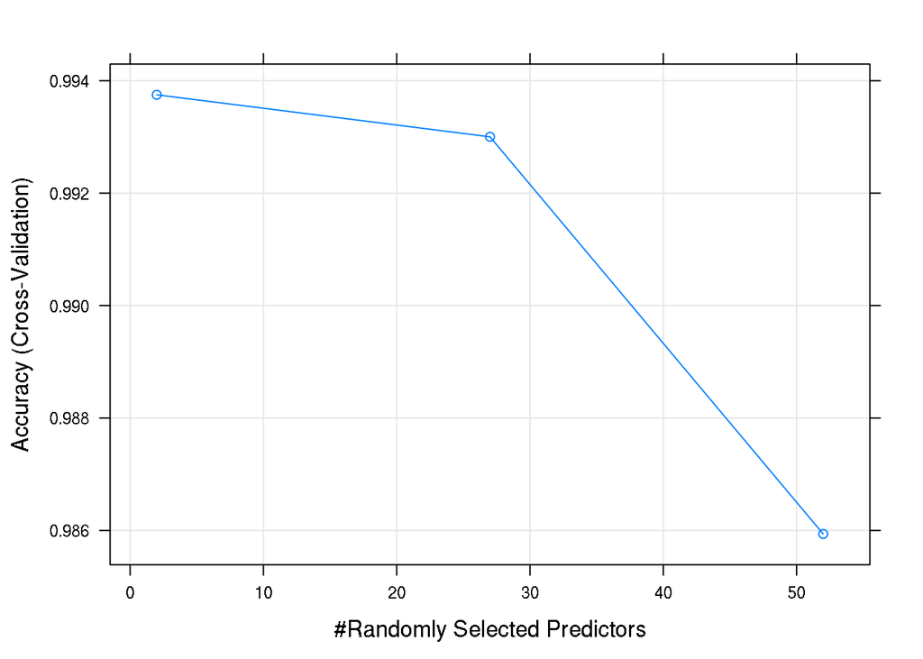

```r
plot(rfModel)
```

```r
# train a gbm model
#gbmModel <- train(classe ~ ., data=training, method="gbm", verbose=FALSE, trControl = trainControl(method = "cv", number = 10))
#save(gbmModel, file="gbmModel.RData")

# loading model previously generated as above to save processing time
load("gbmModel.RData")
gbmModel
```

[output not shown]

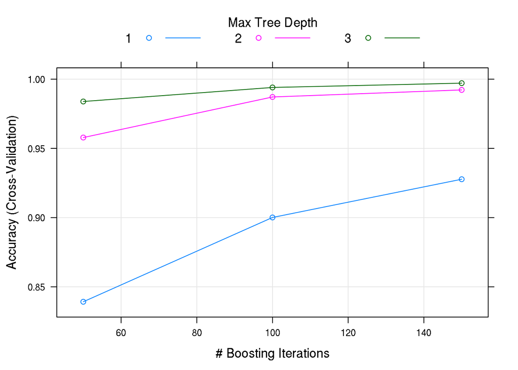

```r
plot(gbmModel)
```

Calculate the out of sample error on random forest model using the validation test set.

```r
validationPred <- predict(rfModel, newdata=validation)

# accuracy of the model
rfAccuracy <- sum(validationPred == validation$classe)/length(validationPred)
rfAccuracy
```

```
## [1] 0.9987765
```

```r
# out of sample error and percentage of out of sample error
oose <- 1 - rfAccuracy
oose
```

```
## [1] 0.001223491
```

The out of sample error is 0.1223491%.

Apply the model to the testing set to generate the predicted values.

```r
testing <- read.csv("data/pml-testing.csv")
preds <- predict(rfModel, testing)
preds
```

```
##  [1] B A B A A E D B A A B C B A E E A B B B
## Levels: A B C D E
```